# How to avoid counfounding in Hedwig’s Study? It depends on which DAG we assume

Joseph Bulbulia

12/01/2021

## Question

Does Psychopathy affect JobLevel over time?

## Which variables do we need to control for?

We assume that

- Job levels are affected by Years + Psychopathy + Age + Male + Education + Time in Job + “U” (an unmeasured effect like priviledge)
- Pyschopathy is affected by Male
- JobTime is affected by Years + Psychopathy (“impulsivit”) + Unmeasured Privilege
- Education is affected by Time (more time to be educated) + Unmeasured Privilege.
- Age is affeced by Years
- Male doesn’t change and U doesn’t change.
- The Year effect stratifies on different levels of Psychopathy (i.e. Psychopathy won’t be invariate over the years)

Now let’s write out our causal model with these assumptions, and see which variables we need to include to understand the relationship between Psychopathic Personality and JobLevel.

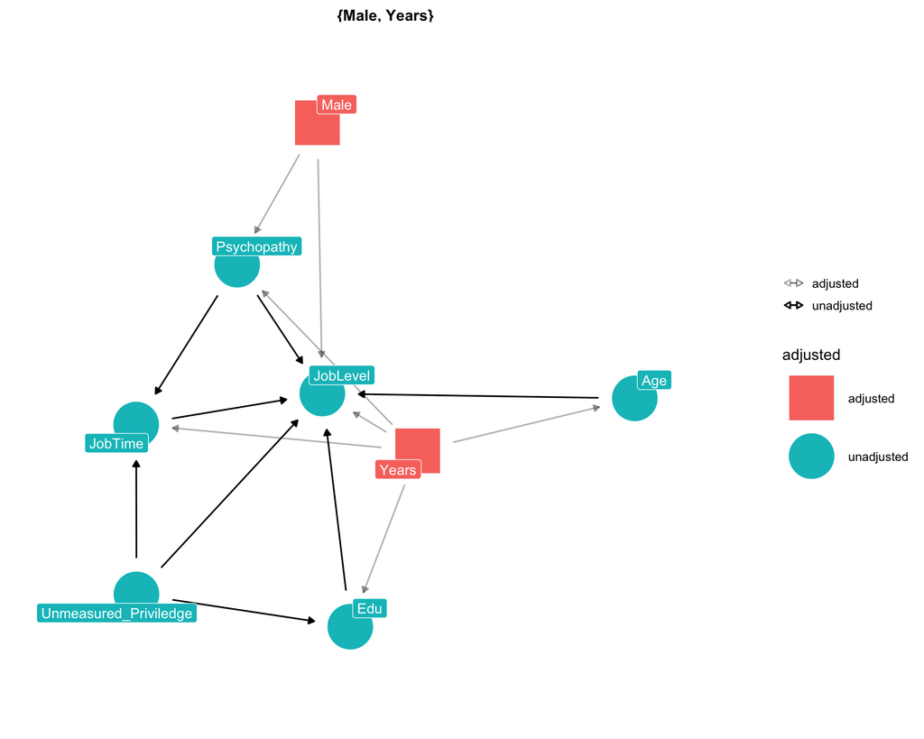

```r
library("dagitty")
library("ggdag")
dag0 <- dagify(
  JobLevel ~ Years + Psycho + Age + Male + Edu + JobTime + U,
  Psycho ~ Male + Years,
  JobTime ~ Years + Psycho + U,
  Edu ~ Years + U,
  Age ~ Years,
  labels = c(
    "Psycho" = "Psychopathy",
    "JobLevel" = "JobLevel",
    "Male" = "Male",
    "Edu" = "Edu",
    "JobTime" = "JobTime",
    "Years" = "Years",
    "Age" = "Age",
    "U" = "Unmeasured_Priviledge"
  )
)

ggdag_adjustment_set(
  dag0,
  text = FALSE,
  use_labels = "label",
  shadow = TRUE,
  exposure =  "Psycho",
  outcome =   "JobLevel",
) + theme_dag_blank()
```

The minimal set is “Male” and “Years.”

What would happen if we were to roll with the “casual salad” approach and include the other variables that might affect Job Level?

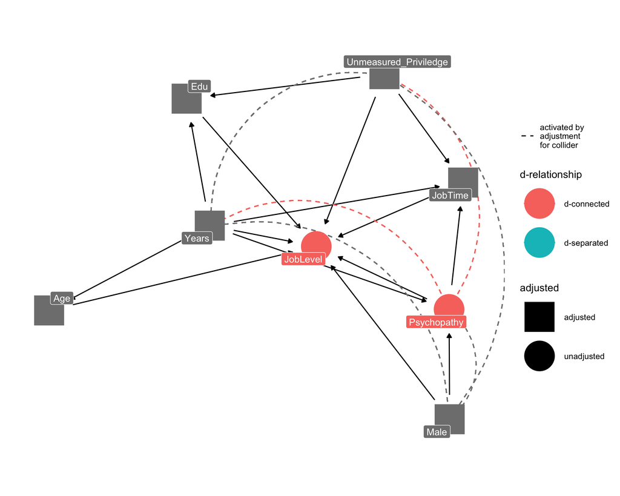

```r
ggdag_dseparated(dag0,
  from = "Psycho",
  to = "JobLevel",
  controlling_for = c("Years", "Male", "Edu", "JobTime", "U", "Age"),
  text = FALSE,
  use_labels = "label"
) + theme_dag_blank()
```

The answer is that we open collider confounds, at least on the assumptions of this DAG. Of course, another DAG might be better, and you should feel free to play with this.

## Our question might differ in which case we’d need a different model

Note, if we wanted to predict Job Level accurately, we *would* want the causal salad model.

## What if we think that all the control variables might affect how psychopathy affects job performance?

Bad luck! No way to close the backdoors unless we can find another instrumental variable.

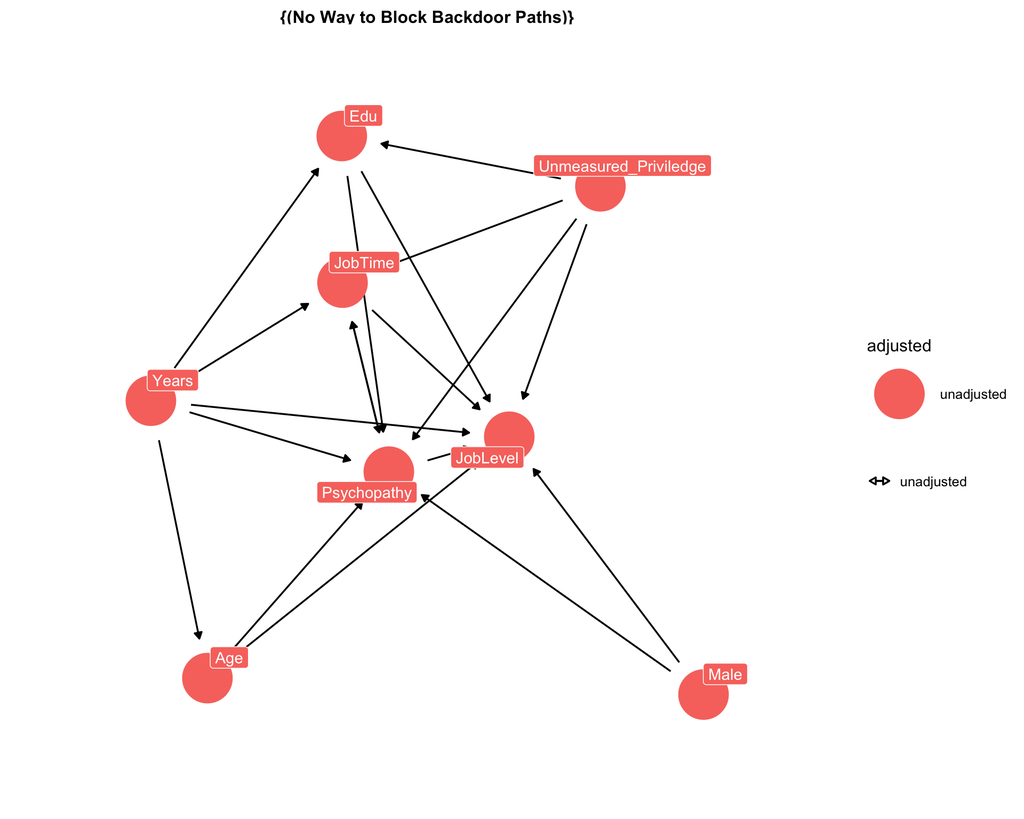

```r
dag03 <- dagify(
  JobLevel ~ Years + Psycho + Age + Male + Edu + JobTime + U,
  Psycho ~ Years + Age + Male + Edu + JobTime + U,
  JobTime ~ Years + Psycho + U,
  Edu ~ Years + U,
  Age ~ Years,
  labels = c(
    "Psycho" = "Psychopathy",
    "JobLevel" = "JobLevel",
    "Male" = "Male",
    "Edu" = "Edu",
    "JobTime" = "JobTime",
    "Years" = "Years",
    "Age" = "Age",
    "U" = "Unmeasured_Priviledge"
  )
)

ggdag_adjustment_set(
  dag03,
  text = FALSE,
  use_labels = "label",
  shadow = TRUE,
  exposure =  "Psycho",
  outcome =   "JobLevel",
) + theme_dag_blank()
```

I doubt we believe such a model, though it might be implied by our decision to include all “control” covariates. In any case, we need to think about causation when adding “controls.”